# Gold Regression

## Introduction

Gold has long been a store of value across many civilizations. Due to its unique combination of physical properties and cultural appeal, gold became a widely accepted medium of exchange. Although no country relies on a gold standard, gold continues to be valued as safe investment especially in times of economic uncertainty. The objective of this project is to predict gold prices using other financial variables such as market indices, commodities, and rates, by applying regression modeling techniques.

## The Data

The data used in this project is from [kaggle](https://www.kaggle.com/datasets/franciscogcc/financial-data). This dataset includes a wide range of economic indicators such as S&P 500, Nasdaq 100, US interest rates, GDP, Silver, Oil, etc. The dataset ranges from 2010 to 2024. In total, there are 47 key features in this dataset with over 3900 rows.

## What is Regression?

Regression is a statistical method used to find the relationship between a dependant variable and one or more independent variables. In simple terms, regression is a mathematical way of sorting which variables have an impact and which do not. According to [Amy Gallo](https://hbr.org/2015/11/a-refresher-on-regression-analysis), "It answers the questions: Which factors matter most? Which can we ignore? How do those factors interact with one another? And, perhaps most important, how certain are we about all these factors?"

```python
import numpy as np
import pandas as pd
import matplotlib.pyplot as plt
import seaborn as sns
```

```python
df = pd.read_csv("financial_regression.csv")
df
```

|  | date | sp500 open | sp500 high | sp500 low | sp500 close | sp500 volume | sp500 high-low | nasdaq open | nasdaq high | nasdaq low | ... | palladium high | palladium low | palladium close | palladium volume | palladium high-low | gold open | gold high | gold low | gold close | gold volume |
| --- | --- | --- | --- | --- | --- | --- | --- | --- | --- | --- | --- | --- | --- | --- | --- | --- | --- | --- | --- | --- | --- |
| 0 | 2010-01-14 | 114.49 | 115.1400 | 114.4200 | 114.93 | 115646960.0 | 0.7200 | 46.26 | 46.520 | 46.2200 | ... | 45.0200 | 43.8600 | 44.84 | 364528.0 | 1.1600 | 111.51 | 112.37 | 110.79 | 112.03 | 18305238.0 |
| 1 | 2010-01-15 | 114.73 | 114.8400 | 113.2000 | 113.64 | 212252769.0 | 1.6400 | 46.46 | 46.550 | 45.6500 | ... | 45.7600 | 44.4000 | 45.76 | 442210.0 | 1.3600 | 111.35 | 112.01 | 110.38 | 110.86 | 18000724.0 |
| 2 | 2010-01-18 | NaN | NaN | NaN | NaN | NaN | NaN | NaN | NaN | NaN | ... | NaN | NaN | NaN | NaN | NaN | NaN | NaN | NaN | NaN | NaN |
| 3 | 2010-01-19 | 113.62 | 115.1300 | 113.5900 | 115.06 | 138671890.0 | 1.5400 | 45.96 | 46.640 | 45.9500 | ... | 47.0800 | 45.7000 | 46.94 | 629150.0 | 1.3800 | 110.95 | 111.75 | 110.83 | 111.52 | 10467927.0 |
| 4 | 2010-01-20 | 114.28 | 114.4500 | 112.9800 | 113.89 | 216330645.0 | 1.4700 | 46.27 | 46.604 | 45.4300 | ... | 47.3100 | 45.1700 | 47.05 | 643198.0 | 2.1400 | 109.97 | 110.05 | 108.46 | 108.94 | 17534231.0 |
| ... | ... | ... | ... | ... | ... | ... | ... | ... | ... | ... | ... | ... | ... | ... | ... | ... | ... | ... | ... | ... | ... |
| 3899 | 2024-10-17 | 585.91 | 586.1200 | 582.1600 | 582.35 | 34393714.0 | 3.9600 | 496.44 | 496.490 | 491.1901 | ... | 96.0259 | 94.5400 | 95.68 | 52414.0 | 1.4859 | 247.75 | 249.06 | 247.62 | 248.63 | 5176170.0 |
| 3900 | 2024-10-18 | 584.07 | 585.3900 | 582.5800 | 584.59 | 37416801.0 | 2.8100 | 494.06 | 495.570 | 493.3000 | ... | 99.6600 | 97.2700 | 99.46 | 205027.0 | 2.3900 | 250.00 | 251.37 | 249.90 | 251.27 | 7833614.0 |
| 3901 | 2024-10-21 | 583.85 | 584.8500 | 580.6001 | 583.63 | 36439010.0 | 4.2499 | 493.25 | 496.230 | 491.3100 | ... | 98.3500 | 95.8900 | 97.35 | 227394.0 | 2.4600 | 252.74 | 253.14 | 250.73 | 251.22 | 9258590.0 |
| 3902 | 2024-10-22 | 581.05 | 584.5000 | 580.3800 | 583.32 | 34183835.0 | 4.1200 | 492.73 | 497.445 | 491.9700 | ... | 99.5899 | 97.9600 | 99.41 | 136431.0 | 1.6299 | 253.06 | 253.94 | 252.52 | 253.93 | 5756321.0 |
| 3903 | 2024-10-23 | 581.26 | 581.7086 | 574.4150 | 577.99 | 47444991.0 | 7.2936 | 493.59 | 494.250 | 485.0500 | ... | 98.5500 | 96.4643 | 97.53 | 81133.0 | 2.0857 | 253.08 | 253.18 | 250.20 | 250.87 | 7899995.0 |

3904 rows × 47 columns

In this dataset, we will use many forms of regression to predict our target variable **gold close**.

## Data Preprocessing

Before we create a regression model for this project, we first need to clean the data. I will start by seeing the amount of null values that are present in the dataset.

```python
print(df.shape)
df.isna().sum()
```

```
(3904, 47)
```

```
date                     0
sp500 open             185
sp500 high             185
sp500 low              185
sp500 close            185
sp500 volume           185
sp500 high-low         185
nasdaq open            185
nasdaq high            185
nasdaq low             185
nasdaq close           185
nasdaq volume          185
nasdaq high-low        185
us_rates_%            3728
CPI                   3728
usd_chf                210
eur_usd                210
GDP                   3847
silver open            185
silver high            185
silver low             185
silver close           185
silver volume          185
silver high-low        185
oil open               185
oil high               185
oil low                185
oil close              185
oil volume             185
oil high-low           185
platinum open          185
platinum high          185
platinum low           185
platinum close         185
platinum volume        185
platinum high-low      185
palladium open         185
palladium high         185
palladium low          185
palladium close        185
palladium volume       185
palladium high-low     185
gold open              185
gold high              185
gold low               185
gold close             185
gold volume            185
dtype: int64
```

From this output, we can conclude that a majority of these columns have 185 null values. Since these are mostly market-based columns, we can assume that these are likely the same days (rows). The macro indicators like us_rates_%, CPI, and GDP have thousands of null values because that data is reported monthy/quarterly, not daily.

### Dropping Rows

Let's try to drop those days/rows and see what happens.

```python
df = df.dropna(subset=[
    'sp500 open', 'sp500 high', 'sp500 low', 'sp500 close',
    'nasdaq open', 'nasdaq high', 'nasdaq low', 'nasdaq close',
    'silver open', 'silver high', 'silver low', 'silver close',
    'oil open', 'oil high', 'oil low', 'oil close',
    'platinum open', 'platinum high', 'platinum low', 'platinum close',
    'palladium open', 'palladium high', 'palladium low', 'palladium close',
    'gold open', 'gold high', 'gold low', 'gold close'
])

print(df.shape)
df.isna().sum()
```

```
(3719, 47)
```

```
date                     0
sp500 open               0
sp500 high               0
sp500 low                0
sp500 close              0
sp500 volume             0
sp500 high-low           0
nasdaq open              0
nasdaq high              0
nasdaq low               0
nasdaq close             0
nasdaq volume            0
nasdaq high-low          0
us_rates_%            3602
CPI                   3602
usd_chf                 42
eur_usd                 42
GDP                   3689
silver open              0
silver high              0
silver low               0
silver close             0
silver volume            0
silver high-low          0
oil open                 0
oil high                 0
oil low                  0
oil close                0
oil volume               0
oil high-low             0
platinum open            0
platinum high            0
platinum low             0
platinum close           0
platinum volume          0
platinum high-low        0
palladium open           0
palladium high           0
palladium low            0
palladium close          0
palladium volume         0
palladium high-low       0
gold open                0
gold high                0
gold low                 0
gold close               0
gold volume              0
dtype: int64
```

As I predicted, the 185 null values are from the same days. Although we are losing 185 days, I think this is an acceptable trade-off since removing them ensures that the dataset remains clean and consistent. It also is only about 4.74% of the entire datset.

### Forward-Filling

Since the macro indicators are valuable economic context that influences gold prices, it probably not the best idea to drop the columns/rows. Instead, we should most likely forward-fill the values.

```python
df = df.copy()

df.loc[:, "date"] = pd.to_datetime(df["date"])
df = df.sort_values("date")

macro_cols = ["us_rates_%", "CPI", "GDP"]
df.loc[:, macro_cols] = df[macro_cols].ffill()

cols_to_fill = ["us_rates_%", "CPI", "GDP", "usd_chf", "eur_usd"]
df[cols_to_fill] = df[cols_to_fill].ffill().bfill()


print(df.shape)
df.isna().sum()
```

```
(3719, 47)
```

```
date                  0
sp500 open            0
sp500 high            0
sp500 low             0
sp500 close           0
sp500 volume          0
sp500 high-low        0
nasdaq open           0
nasdaq high           0
nasdaq low            0
nasdaq close          0
nasdaq volume         0
nasdaq high-low       0
us_rates_%            0
CPI                   0
usd_chf               0
eur_usd               0
GDP                   0
silver open           0
silver high           0
silver low            0
silver close          0
silver volume         0
silver high-low       0
oil open              0
oil high              0
oil low               0
oil close             0
oil volume            0
oil high-low          0
platinum open         0
platinum high         0
platinum low          0
platinum close        0
platinum volume       0
platinum high-low     0
palladium open        0
palladium high        0
palladium low         0
palladium close       0
palladium volume      0
palladium high-low    0
gold open             0
gold high             0
gold low              0
gold close            0
gold volume           0
dtype: int64
```

What this code does is it that it converts the date column into a datetime object. It then sorts the data in chronological order to ensure that the forward-fill happens in the correct sequence. The next two lines defines the macroeconomic variables (interest rate, inflation, GDP) that are updated infrequently. Then forward-fills (ffill) them. This basically means "Use the most recent known value to fill missing ones until a new update appears." Finally, the next two lines ensures complete removal of missing values in both macro and forex columns. Now our data is preprocessed!

## Data Understanding and Visualization

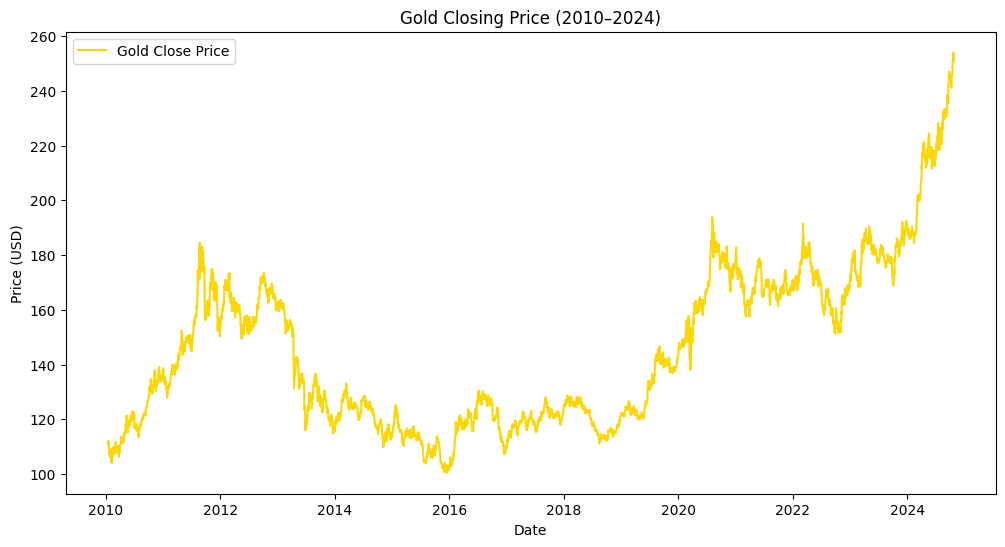

```python
plt.figure(figsize=(12, 6))
plt.plot(df["date"], df["gold close"], color="gold", label="Gold Close Price")
plt.title("Gold Closing Price (2010–2024)")
plt.xlabel("Date")
plt.ylabel("Price (USD)")
plt.legend()
plt.show()
```

First, lets take a look at gold closing prices from 2010 - 2024. We can see that gold prices show strong cyclical movements shaped by global economic events. Gold prices reached record highs in 2011 due to financial uncertainty following the [2008 Great Recession](https://www.bls.gov/opub/btn/volume-2/gold-prices-during-and-after-the-great-recession.htm). In 2013, gold prices began to decline as the economy started to get back to its feet and confidence in equities returned. Between 2014-2018, prices stabilized before another sharp rise during 2019–2021, driven by trade tensions and the COVID-19 pandemic. In more recent years (2022-2024) gold seems to remain volatile and elevated as it hits record highs. This is possibly due to inflation concerns, geopolitical risks, and central bank demand. But from this chart and analysis, we can see how geopolitical and other economic factors effect gold. Understanding these fluctuations through quantitative modeling is essential to uncover the key factors influencing gold price movements over time.

Next let's take a look at the relationships between gold, silver, oil, CPI (inflation), and US interest rates.

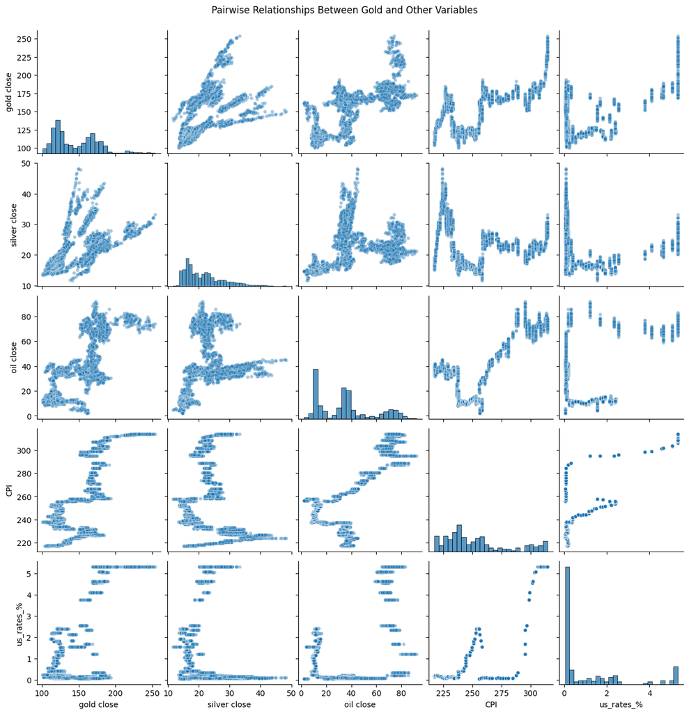

```python
sns.pairplot(df, vars=["gold close", "silver close", "oil close", "CPI", "us_rates_%"],
             plot_kws={"alpha": 0.4, "s": 20})
plt.suptitle("Pairwise Relationships Between Gold and Other Variables", y=1.02)
plt.show()
```

## Experiment 1: Linear Regression Modeling

Now that we have cleaned the data and explored some correlations using our data visualizations, we can start to build our model. For this experiment, I will use a linear regression model.

### Predicting Next Day Close

To predict the next day gold close, I have to align the features from day *t* with the gold closing price from day *t+1*.

```python
df["gold_close_next"] = df["gold close"].shift(-1)
```

This creates a new column where each row’s target is tomorrow’s closing price.

### Split Train / Test Data

```python
from sklearn.model_selection import train_test_split

X = df[[
    "gold open", "gold high", "gold low", "gold volume",
    "silver open", "silver high", "silver low", "silver volume",
    "CPI", "us_rates_%"
]]
y = df["gold_close_next"].dropna()

X = X.iloc[:-1, :]

X_train, X_test, y_train, y_test = train_test_split(
    X, y, test_size=0.2, random_state=42, shuffle=False
)
```

We split our dataframe into X and y. X is the variable that holds our features that serve as predictors, including both market indicators (such as gold and silver prices) and macroeconomic factors (such as the Consumer Price Index and U.S. interest rates). y is the variable that holds our target value which is the next day gold closing price that we aim to predict. After defining these variables, we use scikit-learn’s train_test_split function to divide the dataset into 80% training data and 20% testing data. This means that the model is trained on the majority of data while leaving out 20% for evaluation.

### Creating Linear Regression Pipeline

Next we need to create our linear regression pipeline.

```python
from sklearn.pipeline import Pipeline
from sklearn.preprocessing import StandardScaler
from sklearn.linear_model import LinearRegression

linear_pipeline = Pipeline([
    ('scaler', StandardScaler()),
    ('model', LinearRegression())
])
```

This block of code creates a pipeline that uses scikit-learn's StandardScaler to standardize our numerical features before passing them to a LinearRegression model.

```python
linear_pipeline.fit(X_train, y_train)

y_pred = linear_pipeline.predict(X_test)
```

These lines of code train and test the linear regression model on the training data. By fitting the model to the training set, it learns the relationships between the financial indicators and the gold closing price. We can now see how well the linear regression model performs on the untrained data.

## Experiment 1 Evaluation

Now that the model is trained and tested, we can take a look at how well it performed.

```python
from sklearn.metrics import r2_score, mean_squared_error
import numpy as np

# Evaluate model performance
r2 = r2_score(y_test, y_pred)
rmse = np.sqrt(mean_squared_error(y_test, y_pred))

print("R² Score:", r2)
print("RMSE:", rmse)
```

```
R² Score: 0.9939288269152305
RMSE: 1.7507312413865503
```

The R^2 Score shows how much variation in next-day gold prices the model explains. The closer the score is to 1 the more explanatory power it shows.

The RMSE (Root Mean Squared Error) measures the average difference between the predicted and actual gold prices. In this case it measures the predicition error in USD.

Knowing this, we can see that our R^2 score is very good with a score of 0.99. This means that the model explains about 99% of of the variance in next-day gold prices. With an average RMSE prediction error of about $1.75 per ounce, it indicates the selected features for this experiment do a relatively good job at predicting short-term changes in gold prices.